# DataFest 2024

Jacob Lukasik, John Seifarth, Abhishek Gadhia, Marho Ayanruoh, Will Arsenault

2024-03-16

# DataFest 2024 Analytics and Insight

```r
library(dplyr)
```

```r
library(ggplot2)
```

# Loading all excel spreadsheets into R

```r
responses <- read.csv('responses.csv', header = TRUE)
page_views <- read.csv('page_views.csv', header = TRUE)
media_views <- read.csv('media_views.csv', header = TRUE)
items <- read.csv('items.csv', header = TRUE)
checkpoints_eoc <- read.csv('checkpoints_eoc.csv', header = TRUE)
checkpoints_pulse <- read.csv('checkpoints_pulse.csv', header = TRUE)
```

# Query #1

For one query, we wanted to first focus on institutions themselves and seeing which institutions have a lot of students scoring well on responses.

```r
matching_responses <- responses %>% # create a new data frame that only contains responses that earned full points
  filter(points_possible == points_earned)

institution_ranking <- matching_responses %>% # new data frame that ranks the institutions by how many full points questions
  group_by(institution_id) %>%
  summarise(correct_answers = n())

# adds a new column, total count which is how many times each institution appeared in the dataset
institution_ranking <- institution_ranking %>%
  mutate(total_count = table(responses$institution_id)[as.character(institution_id)])

institution_ranking <- institution_ranking %>% # finally, adds a new column for ratio of full points earned to total responses
  mutate(ratio = correct_answers/total_count)


institution_ranking <- institution_ranking %>% # arranges the institutions in order
  arrange(desc(ratio))

institution_ranking
```

```
## # A tibble: 11 × 4
##    institution_id                       correct_answers total_count ratio
##    <chr>                                          <int> <table[1d]> <table[1d]>
##  1 be43fa14-0937-40a4-bad9-d96294e565e3            3621   5935      0.6101095
##  2 c699dd97-e5a4-49ce-9718-877a81b1d475           20066  35592      0.5637784
##  3 fc5f1b1b-2aeb-4e09-93fc-06fdac0d8030           14890  27187      0.5476882
##  4 292cff87-3c74-4e94-8622-233afb0427dd          479819 902974      0.5313763
##  5 f17495c5-e105-492d-878a-07a03ea3f805           11133  21106      0.5274803
##  6 2f830a93-5a14-4aff-a6e8-c7d2562e2007           24940  49423      0.5046234
##  7 04157183-8665-400a-925d-3bbb70ffe45e            6511  13010      0.5004612
##  8 d2e6c885-36f4-48b9-988b-42eef1f8ed9d           18438  37487      0.4918505
##  9 364da48a-e0b2-4507-bc31-e7761fe16e95           40240  85214      0.4722229
## 10 94a809a9-a0ef-4c47-8d96-3a5ad76f674b          108583 249807      0.4346676
## 11 97aebe75-a051-4bff-a2c0-1d53eb5d9498           62657 157539      0.3977237
```

```
## Defaulting to continuous.
```

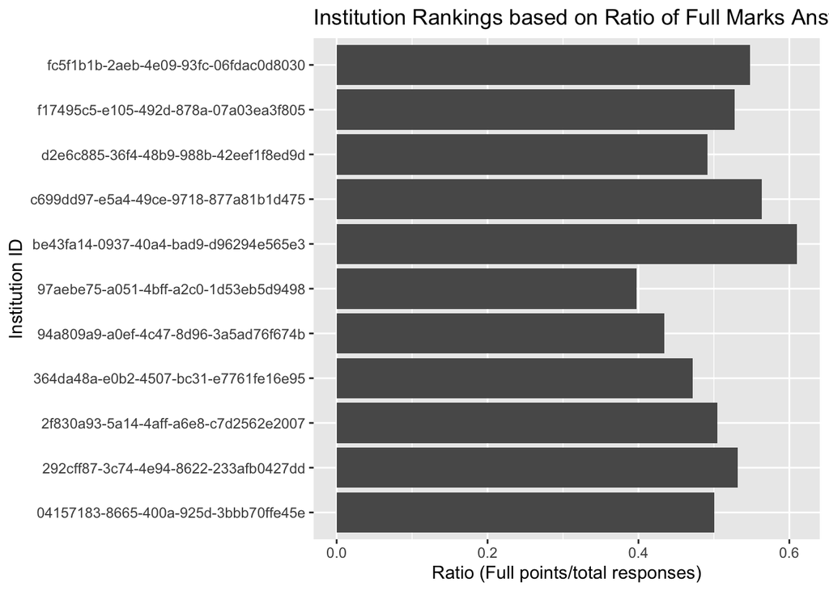

```r
# visualize the rankings using a bar chart
ggplot(data = institution_ranking, aes(x = institution_id, y = ratio)) +
  geom_bar(stat = "identity") +
  labs(x = "Institution ID", y = "Ratio (Full points/total responses)", title = "Institution Rankings based on Ratio of Full Marks Answers") +
  coord_flip()  # rotate x-axis labels for better readability
```

```r
mean(institution_ranking$ratio)
```

```
## [1] 0.5074529
```

From both the above table, as well as the bar plot, we can see that the institution with the ID “be43fa14-0937-40a4-bad9-d96294e565e3” had the highest ratio of correct answers with over 60% of their responses receiving the highest possible number of points. On the contrary, the institution with the id, “97aebe75-a051-4bff-a2c0-1d53eb5d9498” had the lowest ratio with under 40%. Finally, the mean across all of the ratios between the 11 institutions seen in the ranking is 0.5075, or about 51%. This insight can give us clues about how some institutions are having better success than others in terms of learning on the platform. As well as this, it is very interesting that the mean ratio is right around 50%, meaning that almost exactly half of all responses are receiving full possible points.

# Query #2

Another question we had that we wanted to research was which topics took the longest time for students to do. To do this, we wanted to look at the average engagement time for each page.

```r
page_summary <- page_views %>%
  group_by(page) %>%
  summarise(average_time_spent = ((mean(engaged, na.rm = TRUE))/1000), # divide by 1000 to convert the millisecond time value to seconds
            total_page_views = n())

# sort the pages based on average engagement time
page_summary <- page_summary %>%
  arrange(desc(average_time_spent))

page_summary
```

```
## # A tibble: 171 × 3
##    page                                      average_time_spent total_page_views
##    <chr>                                                  <dbl>            <int>
##  1 2.8 Manipulating Data                                   573.             6930
##  2 4.9 From Categorical to Quantitative Exp…               568.             4257
##  3 3.2 Visualizing Distributions with Histo…               565.             5858
##  4 1.5 Save Your Work in R Objects                         557.             7294
##  5 12.5 Confidence Intervals for Other Para…               547.             2997
##  6 4.16 Chapter 4 Review Questions 2                       532.             2610
##  7 11.2 Sampling Distributions of PRE and F                531.             4424
##  8 13.1 What You Have Learned About Explori…               530.              795
##  9 4.2 Explaining One Variable with Another                525.             5170
## 10 14.8 Models with Multiple Categorical Pr…               516.              343
## # ℹ 161 more rows
```

```r
mean(page_summary$average_time_spent)
```

```
## [1] 293.9907
```

From this, we can concur that 2.8 Manipulating Data, 4.9 From Categorical to Quantitative Explanatory Variables, and 3.2 Visualizing Distributions with Histograms were the topics that took students the longest amount of time, on average, to complete. To see if these were necessarily the hardest, we can also create a new data frame, page_correctness, and repeat the method with the ratio of correct answers like we did in the first query we investigated.

# Query #2.1

```r
page_correctness <- matching_responses %>% # create new data frame w/ correctness for each page
  group_by(page) %>%
  summarise(correct_answers = n())

# adds a new column, total count which is how many times each page appeared in the dataset
page_correctness <- page_correctness %>%
  mutate(total_count = table(responses$page)[as.character(page)])

page_correctness <- page_correctness %>% # adds a new column for ratio of full points earned to total responses for each page
  mutate(ratio = correct_answers/total_count)

page_correctness <- page_correctness %>% # arranges the pages in order from worst ratio to best
  arrange(ratio)

page_correctness
```

```
## # A tibble: 158 × 4
##    page                                        correct_answers total_count ratio
##    <chr>                                                 <int> <table[1d]> <tab>
##  1 Midterm 1 Page 2                                          5   429       0.01…
##  2 4.11 Research Design                                    969 15665       0.06…
##  3 14.5 Using `shuffle()` for Targeted Model …              87   887       0.09…
##  4 16.8 Thinking of Factorial Models in Terms…              89   605       0.14…
##  5 3.1 The Concept of Distribution                         993  5944       0.16…
##  6 4.6 Representing Relationships Among Varia…             887  4751       0.18…
##  7 7.9 Partitioning Sums of Squares into Mode…            1042  5422       0.19…
##  8 8.7 Using Shuffle to Compare Models of the…             297  1463       0.20…
##  9 2.2 From Numbers to Data                               2508 12137       0.20…
## 10 6.5 Z-Scores                                           4293 19417       0.22…
## # ℹ 148 more rows
```

Now, lets merge these two data frames and investigate further

```r
merged_page_data <- merge(page_summary, page_correctness, by = 'page', all = TRUE) # merge the two data frames on 'page'

merged_page_data <- merged_page_data %>% # arrange from smallest ratio to largest
  arrange(ratio)

merged_page_data <- na.omit(merged_page_data) # omit values of NA (this is caused by pages that asked students no questions)

merged_page_data
```

```
##                                                                                                    page
## 1                                                                                      Midterm 1 Page 2
## 2                                                                                  4.11 Research Design
## 3                                        14.5 Using `shuffle()` for Targeted Model Comparisons (Part 1)
## 4                                   16.8 Thinking of Factorial Models in Terms of Intercepts and Slopes
## 5                                                                       3.1 The Concept of Distribution
## 6                                                        4.6 Representing Relationships Among Variables
## 7                                                 7.9 Partitioning Sums of Squares into Model and Error
## 8                                                        8.7 Using Shuffle to Compare Models of the DGP
## 9                                                                              2.2 From Numbers to Data
## 10                                                                                         6.5 Z-Scores
## 11                                                 13.1 What You Have Learned About Exploring Variation
## 12                                                 14.7 Deciding Which Predictors to Include in a Model
## 13  16.7 Visually Comparing the Interaction Model to the Additive Model with Two Categorical Predictors
## 14                                                         15.6 Centering a Quantitative Predictor at 0
```

[output cut: 303 more lines]

```
## Defaulting to continuous.
```

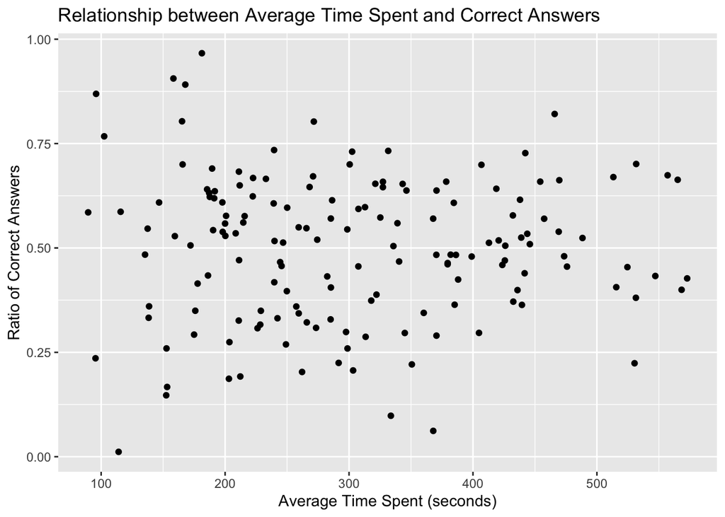

```r
# create a scatterplot between ratio and average time spent to determine if a relationship exists
ggplot(data = merged_page_data, aes(x = average_time_spent, y = ratio)) +
  geom_point() +
  labs(x = "Average Time Spent (seconds)", y = "Ratio of Correct Answers", title = "Relationship between Average Time Spent and Correct Answers")
```

From the above plot, we can see that there is actually no relationship between the average time spent on a page and its apparent difficulty for students.

# Query #3

Keeping on the topic of correct answers, we can also see how well students do between the three activity categories, code, learnosity, and learnosity activity.

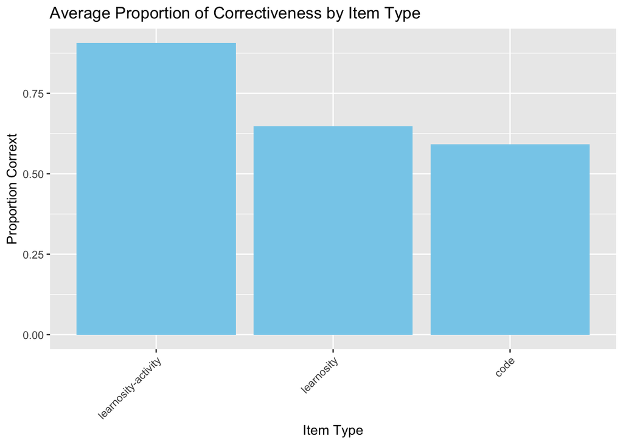

```r
average_score <- responses %>%
  group_by(item_type) %>%
  summarise(average_score = mean(points_earned, na.rm = TRUE))

# plot the average proportion for each item type achieved for each item type
ggplot(data = average_score, aes(x = reorder(item_type, -average_score), y = average_score)) +
  geom_bar(stat = "identity", fill = "skyblue") +
  labs(x = "Item Type", y = "Proportion Corrext", title = "Average Proportion of Correctiveness by Item Type") +
  theme(axis.text.x = element_text(angle = 45, hjust = 1))  # rotate x-axis for readability
```

From this distribution, we can see that it appears the coding activities have the highest difficulties for students. One caviat to this, however, is that the learnosity-activity item types had much fewer observations than either code or learnosity, as well as many of the learnosity-activity types having a lot of NA cases. However, it still tells us a lot we need to know regarding the differences between the code and learnosity item types.

# Query 4

Building upon what we have looked at in the previous queries, we wanted to learn more about how students do depending on what kind of question they are getting

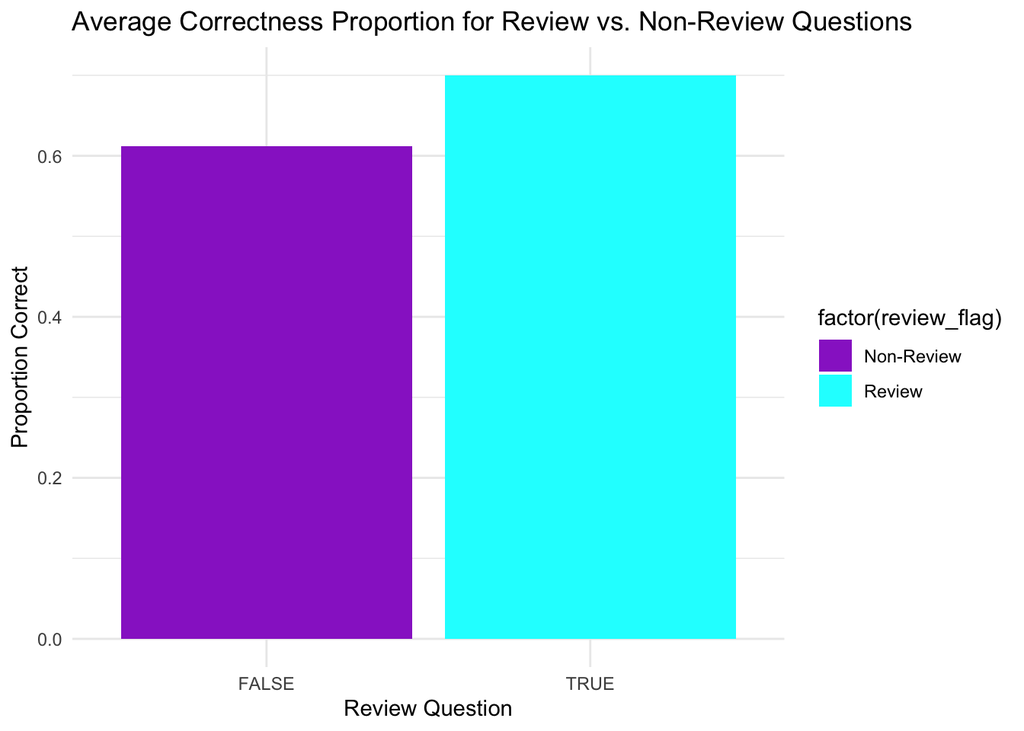

```r
average_score <- responses %>%
  group_by(review_flag) %>%
  summarise(average_score = mean(points_earned, na.rm = TRUE))

# plot the average score achieved for review and non-review questions
ggplot(data = average_score, aes(x = factor(review_flag), y = average_score, fill = factor(review_flag))) +
  geom_bar(stat = "identity") +
  labs(x = "Review Question", y = "Proportion Correct", title = "Average Correctness Proportion for Review vs. Non-Review Questions") +
  scale_fill_manual(values = c("darkorchid", "cyan"), labels = c("Non-Review", "Review")) +
  theme_minimal()
```

Another interesting note, students tend do to about 10% better on review questions then they do on non-review questions. This can tell us, however, that students are seemingly benefiting from these courses and do much better when they revisit material once they learn more.

# General Insight and Conclusions

With our analysis, we really wanted to keen in on the different types of questions that are being asked, and investigating how well students do on those questions. From our first query, we discovered that it greatly differs among different institutions in terms of students’ success with the platform. Without any further information on these institutions, we cannot begin to pick apart why that is, but to those institutions, this can help guide them. Institutions near the 40% range should begin to model their instruction like the institutions near the 60% range and the institutions that are performing well should try to dissect and figure out how they can do even better. Furthermore, our second query, looking at the relationship between time spent on pages and the difficulty of those topics would be very useful for students to know. If students had this knowledge, they would know that they have to put the same amount of effort into a long unit that they would into a short one as there is no way to tell if one will be easier than the other. On the other hand, more research could be done into each individual unit to determine if there is too much or too little content within them that could lead to redundant information being taught and confusion for students down the road. In our third query, we learned that coding items are the hardest for students. With more background information on the students, more work could be done to figure out why that is. Obviously, a coding assignment is going to be much easier for a computer science student than it would be for a finance student pursuing a statistics minor or something along those lines. We believe that with this being known, more research could be done into individual departments within different schools as well to really pin down how to make these coding assignments have a higher success rate. Finally, in our last query, we found that review assignments have about a 10% better average score than non-review assignments. While yes, this is a success, ideally review assignments should have a much higher proportion of correctiveness. To fix this, review could be much more personalized to each student as well as what we said before as it pertains to students’ different backgrounds.

Overall, while we were able to uncover a lot from this dataset, many stones remain unturned. There is a lot of discoveries we made that need more supplemental data to help find a good solution to the things we found. On top of that, in doing this entire analysis in such a short time, we were in a little bit of a pinch with how tight this project was. However, as a group with a very diverse background with a statistics major, a computer science major, and three data science majors, we were all able to grow as data scientists collectively and help eachother using our own individual strengths. We are all very grateful we were able to take part in this event and learn as much as we did.